# Banking_Dataset

### The data is related to direct marketing campaigns of a Portuguese banking institution. The marketing campaigns were based on phone calls. Often, more than one contact to the same client was required, in order to access if the product (bank term deposit) would be subscribed ('yes') or not ('no') subscribed.

```python
import numpy as np
import pandas as pd
import matplotlib.pyplot as plt
```

```python
b = pd.read_csv("D:\Data Science\datasets\Other datasets\BankingDataset.csv")
b.head()
```

|  | age | job | marital | education | default | housing | loan | contact | month | day_of_week | duration | campaign | pdays | previous | poutcome | y |
| --- | --- | --- | --- | --- | --- | --- | --- | --- | --- | --- | --- | --- | --- | --- | --- | --- |
| 0 | 49 | blue-collar | married | basic.9y | unknown | no | no | cellular | nov | wed | 227 | 4 | 999 | 0 | nonexistent | no |
| 1 | 37 | entrepreneur | married | university.degree | no | no | no | telephone | nov | wed | 202 | 2 | 999 | 1 | failure | no |
| 2 | 78 | retired | married | basic.4y | no | no | no | cellular | jul | mon | 1148 | 1 | 999 | 0 | nonexistent | yes |
| 3 | 36 | admin. | married | university.degree | no | yes | no | telephone | may | mon | 120 | 2 | 999 | 0 | nonexistent | no |
| 4 | 59 | retired | divorced | university.degree | no | no | no | cellular | jun | tue | 368 | 2 | 999 | 0 | nonexistent | no |

```python
b.tail()
```

|  | age | job | marital | education | default | housing | loan | contact | month | day_of_week | duration | campaign | pdays | previous | poutcome | y |
| --- | --- | --- | --- | --- | --- | --- | --- | --- | --- | --- | --- | --- | --- | --- | --- | --- |
| 32945 | 28 | services | single | high.school | no | yes | no | cellular | jul | tue | 192 | 1 | 999 | 0 | nonexistent | no |
| 32946 | 52 | technician | married | professional.course | no | yes | no | cellular | nov | fri | 64 | 1 | 999 | 1 | failure | no |
| 32947 | 54 | admin. | married | basic.9y | no | no | yes | cellular | jul | mon | 131 | 4 | 999 | 0 | nonexistent | no |
| 32948 | 29 | admin. | married | university.degree | no | no | no | telephone | may | fri | 165 | 1 | 999 | 0 | nonexistent | no |
| 32949 | 35 | admin. | married | university.degree | no | no | yes | telephone | jun | tue | 544 | 3 | 999 | 0 | nonexistent | no |

### Datatypes of various columns

```python
b.dtypes
```

```
age             int64
job            object
marital        object
education      object
default        object
housing        object
loan           object
contact        object
month          object
day_of_week    object
duration        int64
campaign        int64
pdays           int64
previous        int64
poutcome       object
y              object
dtype: object
```

- Dataset contains int and object datatypes

```python
b.shape
```

```
(32950, 16)
```

- Dataset comprises of 32950 observations and 16 characteristics

```python
b.columns.values
```

```
array(['age', 'job', 'marital', 'education', 'default', 'housing', 'loan',
       'contact', 'month', 'day_of_week', 'duration', 'campaign', 'pdays',
       'previous', 'poutcome', 'y'], dtype=object)
```

### Describing the various values about data for each columns as:-

- Count
- Mean
- Standard Deviation
- Minimum value
- Quartile Range
- Maximum Value

```python
b.describe(include = 'number')
```

|  | age | duration | campaign | pdays | previous |
| --- | --- | --- | --- | --- | --- |
| count | 32950.000000 | 32950.000000 | 32950.000000 | 32950.000000 | 32950.000000 |
| mean | 40.014112 | 258.127466 | 2.560607 | 962.052413 | 0.174719 |
| std | 10.403636 | 258.975917 | 2.752326 | 187.951096 | 0.499025 |
| min | 17.000000 | 0.000000 | 1.000000 | 0.000000 | 0.000000 |
| 25% | 32.000000 | 103.000000 | 1.000000 | 999.000000 | 0.000000 |
| 50% | 38.000000 | 180.000000 | 2.000000 | 999.000000 | 0.000000 |
| 75% | 47.000000 | 319.000000 | 3.000000 | 999.000000 | 0.000000 |
| max | 98.000000 | 4918.000000 | 56.000000 | 999.000000 | 7.000000 |

## Key Observations

- The data describes only the the columns that have integer as the datatype
- We observe 0.00 value at places showing the consistency of the data

```python
b.describe(include = "object")
```

|  | job | marital | education | default | housing | loan | contact | month | day_of_week | poutcome | y |
| --- | --- | --- | --- | --- | --- | --- | --- | --- | --- | --- | --- |
| count | 32950 | 32950 | 32950 | 32950 | 32950 | 32950 | 32950 | 32950 | 32950 | 32950 | 32950 |
| unique | 12 | 4 | 8 | 3 | 3 | 3 | 2 | 10 | 5 | 3 | 2 |
| top | admin. | married | university.degree | no | yes | no | cellular | may | thu | nonexistent | no |
| freq | 8314 | 19953 | 9736 | 26007 | 17254 | 27131 | 20908 | 11011 | 6857 | 28416 | 29238 |

## Key observations

- The data descibes only the columns that have object datatype
- Job column has most unique value item i.e 12
- Column 'y' has the highest frequency among all

# Checking for the null values

```python
print(b.isnull().sum())
```

```
age            0
job            0
marital        0
education      0
default        0
housing        0
loan           0
contact        0
month          0
day_of_week    0
duration       0
campaign       0
pdays          0
previous       0
poutcome       0
y              0
dtype: int64
```

# Histogram

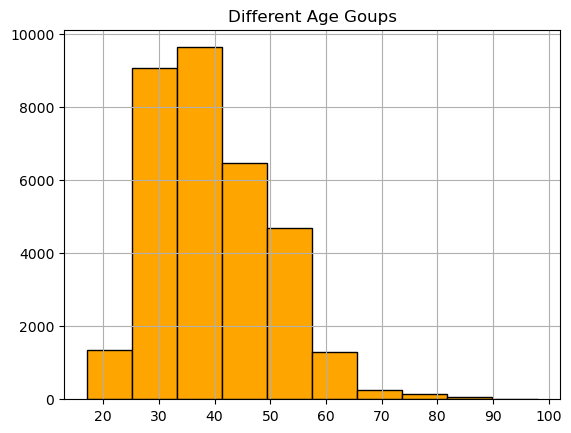

```python
b.hist(['age'], color = 'orange', edgecolor = 'black')
plt.title('Different Age Goups')
```

- The histogram depicts that of the people contacted by the bank, maximum people lie in the age range 33 - 42

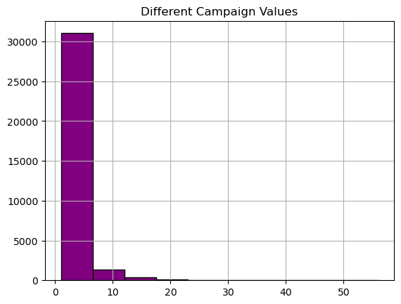

```python
b.hist(['campaign'], color = 'purple', edgecolor = 'black')
plt.title('Different Campaign Values')
```

[figure not shown]

```python
b.hist(['pdays'], color = 'brown', edgecolor = 'black')
plt.title('P-Days')
```

# Bar Graphs

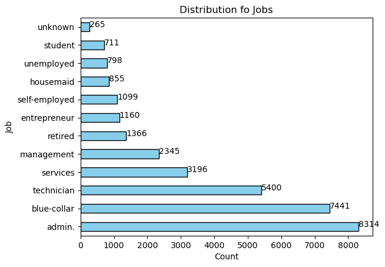

```python
job_counts = b['job'].value_counts()
ax = job_counts.plot(kind = 'barh', color = 'skyblue', edgecolor='black')
for index, value in enumerate(job_counts):
    ax.text(value, index, str(value))

plt.xlabel('Count')
plt.ylabel('Job')
plt.title('Distribution fo Jobs')

plt.show()
```

- The bar graph shows the count of people various jobs approached by bank. The job of 'admin' recieved maximum calls of all.

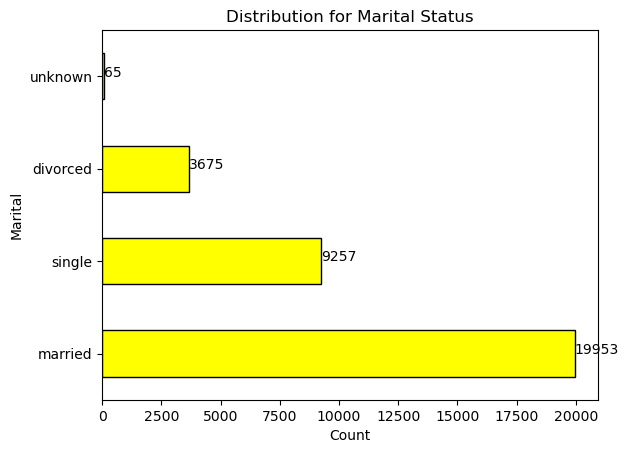

```python
marry = b['marital'].value_counts()
ax = marry.plot(kind = 'barh', color = 'yellow', edgecolor='black')
for index, value in enumerate(marry):
    ax.text(value, index, str(value))

plt.xlabel('Count')
plt.ylabel('Marital')
plt.title('Distribution for Marital Status')

plt.show()
```

- The bar graph show the count for people depicting their marital status. From the data, 19953 people were married, 9257 were single, 3675 were divorced and record for 65 was unknown.

[figure not shown]

```python
edu = b['education'].value_counts()
ax = edu.plot(kind = 'barh', color = 'red', edgecolor='black')
for index, value in enumerate():
    ax.text(value, index, str(value))

plt.xlabel('Count')
plt.ylabel('Education Status')
plt.title('Distribution for Education Status')

plt.show()
```

- The bar graph shows the count for people depicting thier education qualification status. Most of them have done their universtiy degrees.

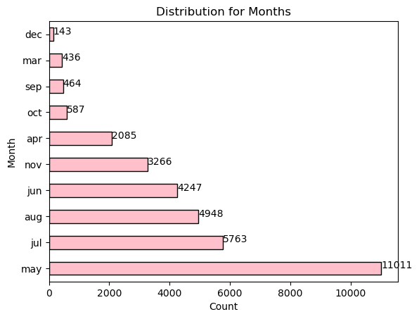

```python
mon = b['month'].value_counts()
ax = mon.plot(kind = 'barh', color = 'pink', edgecolor='black')
for index, value in enumerate(mon):
    ax.text(value, index, str(value))

plt.xlabel('Count')
plt.ylabel('Month')
plt.title('Distribution for Months')

plt.show()
```

- The data shows which month recorded the most number of reach outs from the bank

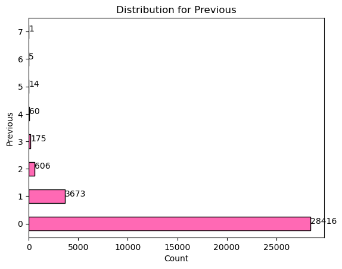

```python
prev = b['previous'].value_counts()
ax = prev.plot(kind = 'barh', color = 'hotpink', edgecolor='black')
for index, value in enumerate(prev):
    ax.text(value, index, str(value))

plt.xlabel('Count')
plt.ylabel('Previous')
plt.title('Distribution for Previous')

plt.show()
```

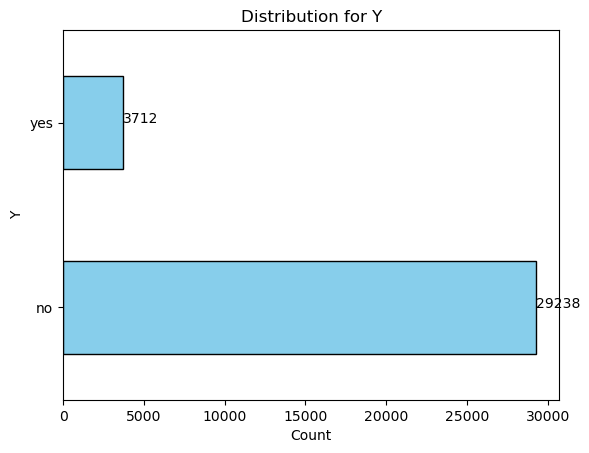

```python
y = b['y'].value_counts()
ax = y.plot(kind = 'barh', color = 'skyblue', edgecolor='black')
for index, value in enumerate(y):
    ax.text(value, index, str(value))

plt.xlabel('Count')
plt.ylabel('Y')
plt.title('Distribution for Y')

plt.show()
```

# Pie Chart

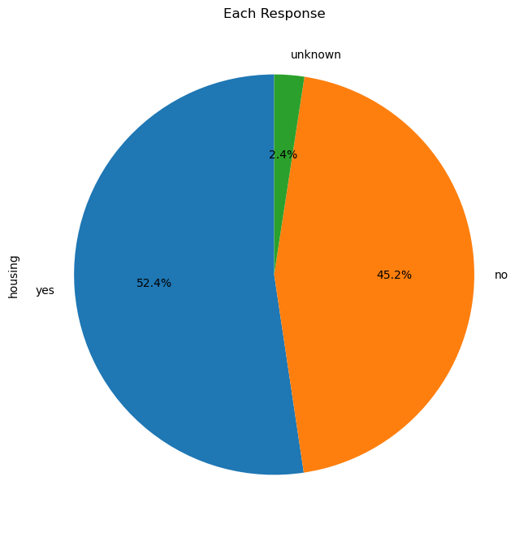

```python
house = b['housing'].value_counts()
house.plot.pie(autopct = '%1.1f%%', startangle = 90, figsize = (8,8), title = 'Each Response')
```

- The data has 52.4% yes for housing, 45.2% no for housing and the remaining for unkown.

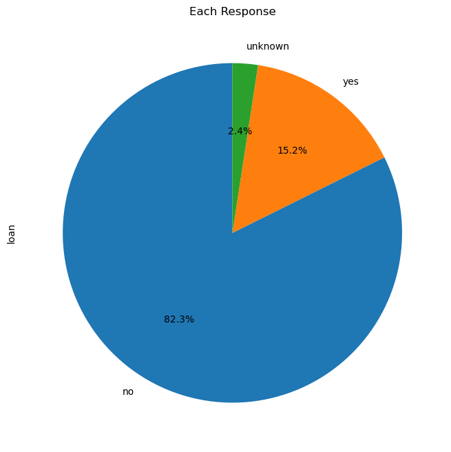

```python
loans = b['loan'].value_counts()
loans.plot.pie(autopct = '%1.1f%%', startangle = 90, figsize = (8,8), title = 'Each Response')
```

- The data shows that 82.3% did not take the loan, 15.2% took the loan and data for about 2.4% people are unknown.

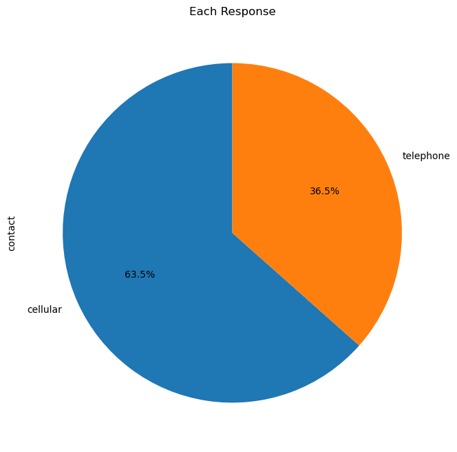

```python
contacts = b['contact'].value_counts()
contacts.plot.pie(autopct = '%1.1f%%', startangle = 90, figsize = (8,8), title = 'Each Response')
```

- The data shows that 63.5% people gave their cellular number and 36.5% people gave their telephone number.

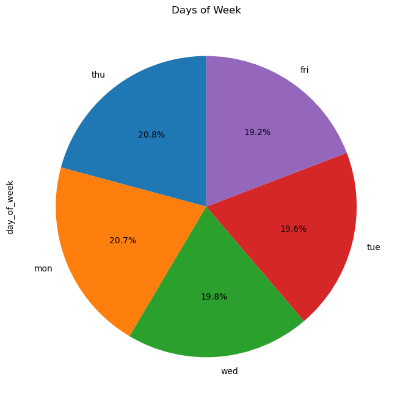

```python
week = b['day_of_week'].value_counts()
week.plot.pie(autopct = '%1.1f%%', startangle = 90, figsize = (8,8), title = 'Days of Week')
```

- The data shows that the maximum calls were made on Thursday i.e 20.8% followed by Monday(20.7%) and so on.

[figure not shown]

```python
prev = b['previous'].value_counts()
prev.plot.pie(autopct = '%1.1f%%', startangle = 90, figsize = (8,8), title = 'Previous Values')
```

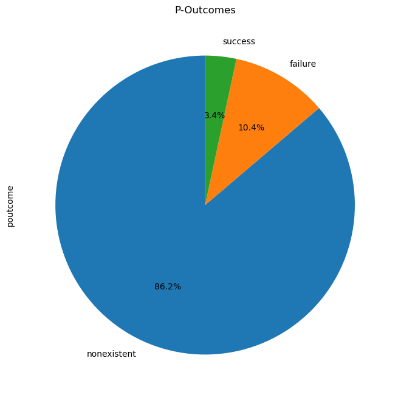

```python
p = b['poutcome'].value_counts()
p.plot.pie(autopct = '%1.1f%%', startangle = 90, figsize = (8,8), title = 'P-Outcomes')
```

- The data shows the outcomes for various calls made by the bank. 86.2% are nonexistent, 10.4% are failures and only 3.4% are success.

# Box Plot

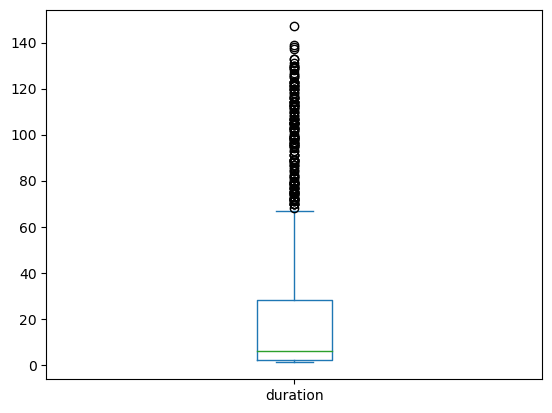

```python
dur = b['duration'].value_counts()
dur.plot.box()
```